# Assessment_1

Bailey Dalton

2024-11-11

### Section 1: Loading Libraries

```r
# Read in dataset
LifeExp_data <- read.csv("data/life-expectancy-un-vs-gdp-per-capita-wb.csv")
```

### Section 2: Research Question

This report will explore the relationship between GDP per capita, a key indicator of a country’s wealth, and its correlation with life expectancy and population across multiple countries from 2005 to 2020. The analysis aims to determine whether GDP directly influences both life expectancy and population size during this period.

### Section 3: Data Set Introduction

The data used in this report (available [here](https://ourworldindata.org/life-expectancy)) is sourced from the *Life Expectancy vs. GDP per Capita, 2022* chart found in the *Population and Demographic Change* topic on [Our World in Data](https://ourworldindata.org/). It is intended to investigate the relationship between life expectancy and various economic and demographic variables across multiple countries over several decades. A link to the location of the data used in this report is provided.

The dataset includes thousands of observations across many countries around the wold and through multiple decades. The variables in the dataset provide insights into the economic and demographic factors that influence life expectancy globally.

```r
# Retrieve the variable names from LifeExp_data
variable_names <- colnames(LifeExp_data)

variable_names_table <- data.frame(variable_names)


kable(variable_names_table, caption = "Table of column names")
```

Table of column names

| variable_names |
| --- |
| Entity |
| Code |
| Year |
| Life.expectancy…Sex..all…Age..0…Variant..estimates |
| GDP.per.capita..PPP..constant.2017.international… |
| Population..historical. |
| Continent |

### Section 4: Data Set Description

```r
# Data cleanup and wrangling to ensure data fits correct specifications for assessment 1
LifeExp_data <- LifeExp_data %>%
  # rename columns to simplify
  rename(
    Country = Entity,
    Life_expectancy = Life.expectancy...Sex..all...Age..0...Variant..estimates,
    GDP_per_capita = GDP.per.capita..PPP..constant.2017.international...,
    Population = Population..historical.
  ) %>%
  # Select only relevant variables
  select(Country, Year, Life_expectancy, GDP_per_capita, Population) %>%
  # Remove missing values
  filter(!is.na(GDP_per_capita) & !is.na(Life_expectancy) & !is.na(Population)) %>%
  # Filter to keep four years (in 5-year intervals), reducing rows to < 1000
  filter(Year %in% c(2005, 2010, 2015, 2020))


glimpse(LifeExp_data)
```

```
## Rows: 787
## Columns: 5
## $ Country         <chr> "Afghanistan", "Afghanistan", "Afghanistan", "Afghanis…
## $ Year            <int> 2005, 2010, 2015, 2020, 2005, 2010, 2015, 2020, 2005, …
## $ Life_expectancy <dbl> 58.247, 60.702, 62.270, 61.454, 76.427, 78.414, 78.358…
## $ GDP_per_capita  <dbl> 1352.321, 2026.164, 2108.714, 1968.341, 8040.121, 1074…
## $ Population      <dbl> 24404574, 28284088, 33831765, 39068978, 3076155, 29287…
```

The data set has undergone data wrangling and cleanup to ensure that it fits within the desired assessment specifications. The main transformations include selecting only the 5 columns/variables (**Country**, **Year**, **GDP per Capita**, **Life Expectancy**, and **Population**), removing missing values and filtering the Years variables for years 2005, 2010, 2015 & 2020.

Following these transformations, the dataset is ready for analysis and contains 787 observatinos and 5 variables.

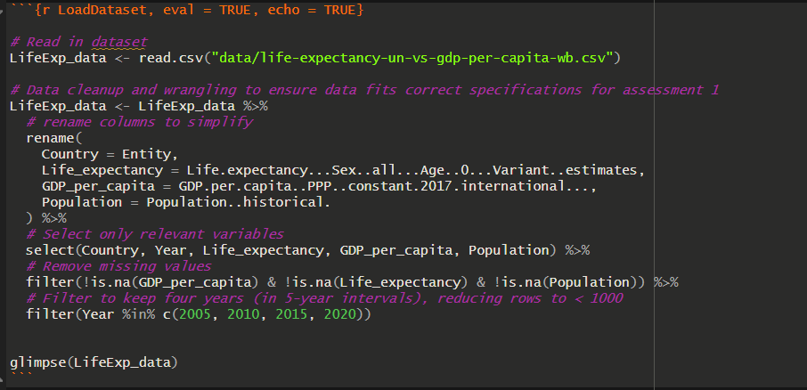

Screenshot of Code

```r
knitr::include_graphics("Image/Screenshot_code.PNG")
```

```r
str(LifeExp_data[1:2, ])
```

```
## 'data.frame':    2 obs. of  5 variables:
##  $ Country        : chr  "Afghanistan" "Afghanistan"
##  $ Year           : int  2005 2010
##  $ Life_expectancy: num  58.2 60.7
##  $ GDP_per_capita : num  1352 2026
##  $ Population     : num  24404574 28284088
```